# Psychoinformatics - Week 4 (Exercises)

by 王紹安 (b09705017@ntu.edu.tw)

## 1 Analyze what videos go viral? (8 points)

Please use [YouTube APIs](https://developers.google.com/youtube/v3/code_samples/python) to carry out a data-driven or hypothesis-driven microstudy about the characteristics of viral videos.

You need to present, here in this notebook, AT LEAST two **statistical** figures or tables as supporting evidence for your arguments. Each of these figures/tables deserves 4 points.

```python
import googleapiclient.discovery
import googleapiclient.errors
import requests

API_KEY = 'AIzaSyDC85dsIL-GKIXy3cZg0i6ccNqAylEv4Hk'
from apiclient.discovery import build
youtube = build('youtube', 'v3', developerKey=API_KEY)
result = youtube.videos().list(part='snippet, contentDetails, statistics',
                               chart='mostPopular',
                               regionCode='TW', maxResults=500).execute()
```

```python
result2 = youtube.videos().list(part='snippet, contentDetails, statistics',
                                chart='mostPopular', regionCode='TW',
                                maxResults=500, pageToken=result['nextPageToken']).execute()
```

```python
result3 = youtube.videos().list(part='snippet, contentDetails, statistics',
                                chart='mostPopular', regionCode='TW', maxResults=500,
                                pageToken=result2['nextPageToken']).execute()
```

```python
result4 = youtube.videos().list(part='snippet, contentDetails, statistics',
                                chart='mostPopular', regionCode='TW', maxResults=500,
                                pageToken=result3['nextPageToken']).execute()
```

```python
from pandas import json_normalize
import json
category_dict = {
    '1': 'Film & Animation',
    '2': 'Autos & Vehicles',
    '10': 'Music',
    '15': 'Pets & Animals',
    '17': 'Sports',
    '19': 'Travel & Events',
    '20': 'Gaming',
    '22': 'People & Blogs',
    '23': 'Comedy',
    '24': 'Entertainment',
    '25': 'News & Politics',
    '26': 'Howto & Style',
    '27': 'Education',
    '28': 'Science & Technology',
    '29': 'Nonprofits & Activism'
}

df = json_normalize(result['items']) #Results contain the required data
df1 = json_normalize(result2['items'])
df2 = json_normalize(result3['items'])
df3 = json_normalize(result4['items'])
category_df = df['snippet.categoryId'].append(df1['snippet.categoryId'])
category_df = category_df.append(df2['snippet.categoryId'])
category_df = category_df.append(df3['snippet.categoryId'])

category_df = category_df.reset_index()
```

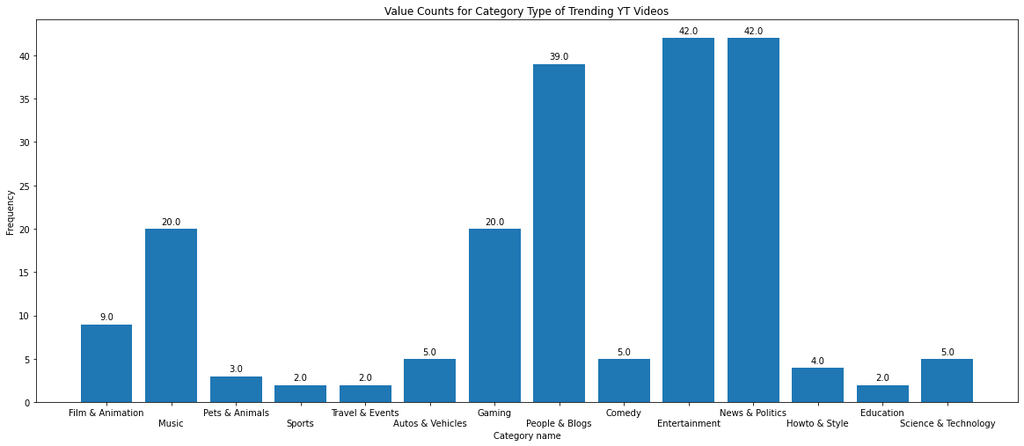

```python
from matplotlib import pyplot as plt
import pandas as pd
import base
category_count = category_df.apply(pd.Series.value_counts).rename(index=category_dict)
category_count.drop('index', 1, inplace=True)
category_count = category_count.dropna()
plt.rcParams['figure.figsize'] = (20, 8)
fig, ax = plt.subplots()
rect = ax.bar(category_count.index, category_count['snippet.categoryId'], align='center')
base.label_stagger(ax)
plt.title('Value Counts for Category Type of Trending YT Videos')
plt.xlabel('Category name')
plt.ylabel('Frequency')
base.autolabel(rect)
```

資料來源為 youtube api 的熱門影片，而我拿了前 200 筆來做統計，上圖是用長條圖來看影片的 category 與熱門程度是否有關連，而我們可以發現 `Entertainment` 與 `News & Politics` 佔最大比例，再來是 `People & Blogs`，可能是因為目前大眾使用 youtube 大部分時間皆在放鬆身心或是關心時事，因此跟休閒娛樂、時事相關的類別會較容易上熱門影片。

### 影片長度是否會與影片熱門程度有關連

|  | duration |
| --- | --- |
| count | 200.000000 |
| mean | 2951.615000 |
| std | 6470.701359 |
| min | 27.000000 |
| 25% | 428.000000 |
| 50% | 744.000000 |
| 75% | 2774.000000 |
| max | 42901.000000 |

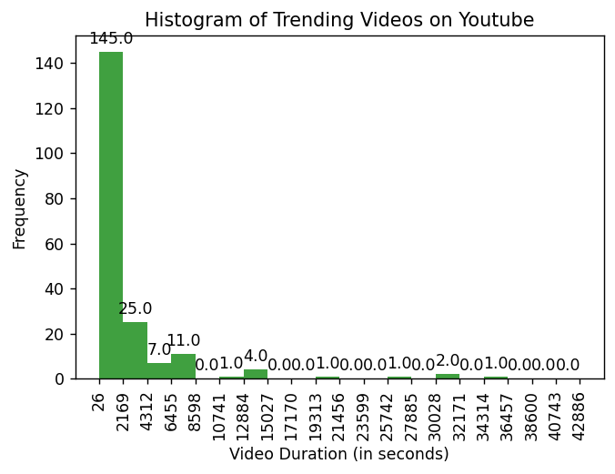

```python
%matplotlib inline
import isodate
import datetime
import seaborn as sns
duration_df = df['contentDetails.duration'].apply(lambda x: isodate.parse_duration(x).seconds)
duration_df1 = df1['contentDetails.duration'].apply(lambda x: isodate.parse_duration(x).seconds)
duration_df2 = df2['contentDetails.duration'].apply(lambda x: isodate.parse_duration(x).seconds)
duration_df3 = df3['contentDetails.duration'].apply(lambda x: isodate.parse_duration(x).seconds)
duration_df = duration_df.append(duration_df1)
duration_df = duration_df.append(duration_df2)
duration_df = duration_df.append(duration_df3)
duration_df = pd.DataFrame(duration_df)
duration_df = duration_df.reset_index()
duration_df.drop('index', 1, inplace=True)
duration_df = duration_df.rename(columns={'contentDetails.duration': 'duration'})
display(duration_df.describe())
fig, ax = plt.subplots()
fig.dpi = 125
bins = [*range(duration_df.duration.min() - 1, duration_df.duration.max() + 1, int((duration_df.duration.max() - duration_df.duration.min()) / 20))]
counts, bins, patches = ax.hist(duration_df.duration, bins=bins, alpha=0.75, color='g')
ax.set_xticks([i for i in bins])
plt.xticks(rotation='vertical')
base.autolabel(patches, fontsize=10)

plt.title('Histogram of Trending Videos on Youtube')
plt.xlabel('Video Duration (in seconds)')
plt.ylabel('Frequency')
plt.show()
```

#### 由上面的 histogram 可看出大部分的影片長度皆偏短，平均 2951 甚至高於第三四分位數 2774，可以推測現代人追求速食文化，會觀看的影片長度普遍不超過 30 分鐘，較短時長的影片會較容易上熱門。

### Please submit this file to NTU COOL before next Monday (10/25).